# Single-locus validation of the BC2S3 simulation

Author

Fausto Rodríguez-Zapata

Published

June 17, 2026

**Repo:** sawers-rellan-labs/zealtiger

Does the Broman/simcross BC2S3 simulation reproduce the **single-locus breeding-scheme expectation** for the REF/Het/ALT genome fractions? This notebook runs that check. The full reasoning — why it is a *circularity* check, why Hotelling and not Pearson, why Mb on real marker coordinates, the ergodicity distinction, and the three-`f_i` bias decomposition — is the prose companion `docs/13-single-locus-validation.md`. The *size-distribution* and interference panels live in the simulation notebook (`nil_introgression_1400.qmd`); RTIGER recovery is layer 2 (a later notebook).

## Setup

```r
library(tidyverse)
library(simcross)
library(patchwork)
purrr::walk(fs::dir_ls("R", glob = "*.R"), source)  # incl. R/07_single_locus.R
set.seed(params$seed)

anchors <- readRDS(params$map)
ped     <- bc2s3_pedigree()
ccl     <- anchors |>
  dplyr::group_by(chr) |>
  dplyr::summarise(L = max(cm), .groups = "drop") |>
  dplyr::arrange(chr)
cat("simcross:", as.character(packageVersion("simcross")),
    "| anchors:", nrow(anchors), "| N:", params$n, "| markers:", params$markers, "\n")
```

```
simcross: 0.8 | anchors: 19486 | N: 1500 | markers: 20000
```

## 1. The single-locus expectation (BC2S3 transition matrix)

The genotype distribution at any single locus after F1 → 2 backcrosses → 3 selfings, from the breeding-scheme transition matrices (map- and interference-independent — a marginal quantity).

```r
p0 <- single_locus_p0(n_bc = 2L, n_self = 3L)
tibble(state = names(p0), expected = as.numeric(p0)) |>
  mutate(note = c("hom recurrent", "het", "hom donor")) |>
  knitr::kable(digits = 6)
```

| state | expected | note |
| --- | --- | --- |
| REF | 0.859375 | hom recurrent |
| Het | 0.031250 | het |
| ALT | 0.109375 | hom donor |

```r
cat(sprintf("donor dosage = ALT + 0.5*Het = %.4f (expect 0.1250)\n",
            p0["ALT"] + 0.5 * p0["Het"]))
```

```
donor dosage = ALT + 0.5*Het = 0.1250 (expect 0.1250)
```

## 2. f_i validation (Mb-based, Hotelling)

Simulate `n` NILs, tabulate per-NIL Mb fractions on a marker grid, and test the population means against `p0` with the design-correct Hotelling/Wald χ²(2) (sample = unit; empirical between-sample covariance — **not** per-marker binomial, which linkage overdispersion would make reject a correct sampler).

```r
markers <- build_marker_grid(anchors, n_markers = params$markers)
F <- t(vapply(seq_len(params$n), function(i)
  state_fractions_mb(markers,
    simulate_sample_dosage(ped, ccl, markers, m = params$m, p = params$p)),
  numeric(3)))
colnames(F) <- c("REF", "Het", "ALT")
res <- hotelling_fractions(F, p0)
knitr::kable(res$table, digits = 5)
```

| state | expected | estimate | se | ci_lo | ci_hi | sd_fi | in_ci |
| --- | --- | --- | --- | --- | --- | --- | --- |
| REF | 0.85938 | 0.85900 | 0.00170 | 0.85567 | 0.86233 | 0.06579 | TRUE |
| Het | 0.03125 | 0.02985 | 0.00072 | 0.02843 | 0.03126 | 0.02794 | TRUE |
| ALT | 0.10938 | 0.11115 | 0.00153 | 0.10816 | 0.11414 | 0.05915 | TRUE |

```r
cat(sprintf("Hotelling T^2 = %.3f (df=2), chi2 p = %.4g | N_eff(ALT) = %.1f vs %d markers\n",
            res$T2, res$p_chisq,
            with(res$table[res$table$state == "ALT", ], expected*(1-expected)/sd_fi^2),
            nrow(markers)))
```

```
Hotelling T^2 = 5.206 (df=2), chi2 p = 0.07405 | N_eff(ALT) = 27.8 vs 20001 markers
```

```r
cat(if (all(res$table$in_ci)) "PASS: all expectations inside 95% Wald CIs.\n" else
    "CHECK: an expectation outside its CI.\n")
```

```
PASS: all expectations inside 95% Wald CIs.
```

The fractions span ~2 orders of magnitude, so a single linear forest plot can show magnitude *or* intervals but not both. Panel **A** (log axis) carries magnitude; panel **B** (standardized deviation, ±1.96 band) carries the pass criterion — scale-free.

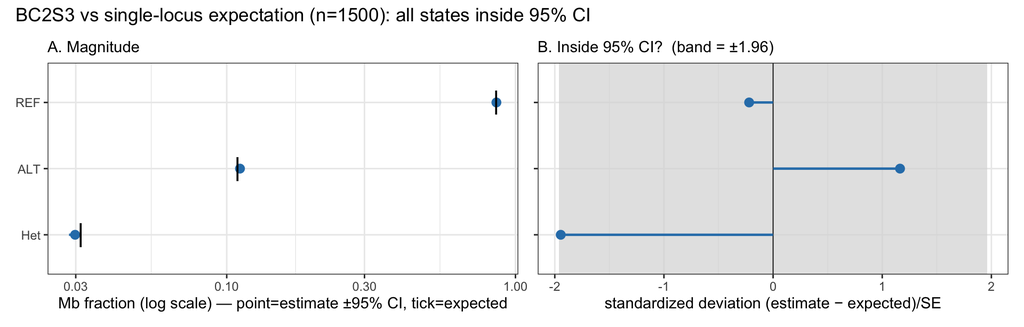

```r
plot_fraction_forest(res$table,
  title = sprintf("BC2S3 vs single-locus expectation (n=%d): all states inside 95%% CI",
                  params$n))
```

`N_eff ≈ 28` (not the marker count) is the ergodicity-limited effective sample size: with ~33 crossovers/genome the per-NIL fraction averages over few independent blocks, so the right SE is `sd(f_i)/√N`, not a per-marker binomial (see `docs/13` §5b).